# report

Jason Su

August 9, 2018

# Probability practice

## Part A

From the question, we know that $P_{RC}=0.3; P_{Y|RC}=0.5; P_{Y}=0.65$. Therefore, we could set up equation as followed:
$$P_{Y} = P_{Y,RC} + P_{Y,TC}$$
$$\Rightarrow P_{Y}=P(Y | RC) * P_{RC} + P(Y | PC) * P_{TC}$$
$$\Rightarrow 0.65 = 0.5 * 0.3 + P(Y|PC) * 0.7$$
We got,
$$P(Y|PC) = \frac{0.65 - 0.5*0.3}{0.7}$$
$$\Rightarrow P(Y|PC) = \frac{5}{7}$$
Around 71.43% of people who are truthful clickers answered yes.

## Part B

We want to get the probability of having the disease based on getting positive result for the test. Let’s denote it as $P(T | P)$.

According to the Bayes’ theorem,
$$P(T|P) = \frac{P_{T,P}}{P_{p}}$$
$$\Rightarrow P(T|P) = \frac{P(P|T)*P_{T}}{P(P|T)*P_{T} + P(P|F)*P_{F}}$$
According to the question, we got $P_{T}=0.000025; P(P|T)=0.993; P(P|F)=1-0.9999=0.0001$

$$\Rightarrow P(T|P) = \frac{0.993*0.000025}{0.993*0.000025 + 0.0001*0.999975}$$

$$\Rightarrow P(T|P) \approx 0.1989$$
The probability of having the disease is about 19.89%.

Problems in implementing a universal testing policy:

1. The probability of having the disease when getting positive result is actually not high. The result might cause unnecessary panic;
2. All assumed probabilities need to be very accurate which might be hard to achieve in reality.

# Exploratory analysis: green buildings

```r
library(ggplot2)
dat=read.csv("greenbuildings.csv")
```

## 1. Is it reasonable to remoeve low occupied outliers?

### *“I decided to remove these buildings from consideration, on the theory that these buildings might have something weird going on with them, and could potentially distort the analysis.”*

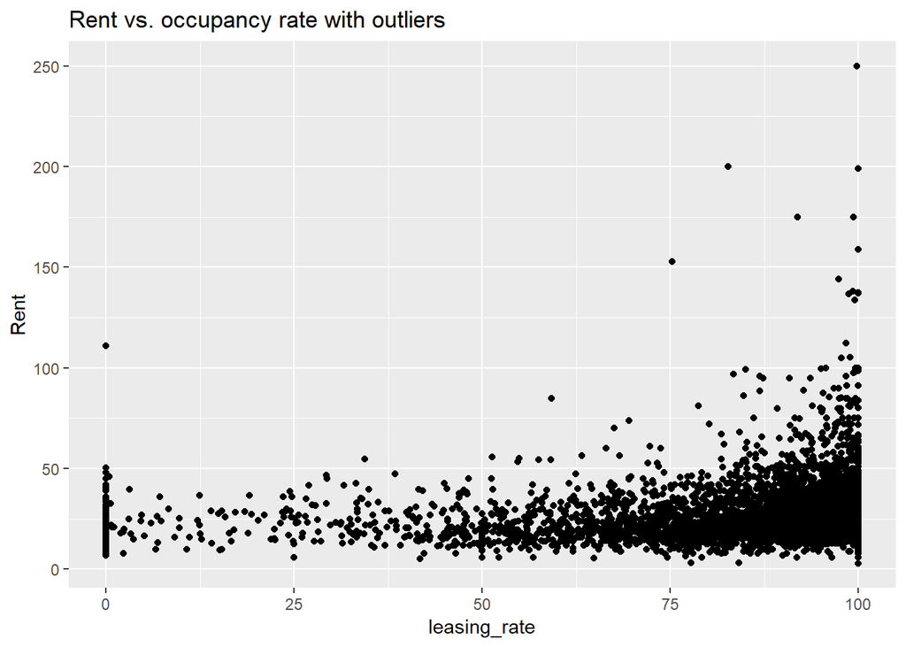

```r
par(mfrow=c(1,2))
greenbuilding = dat[,-c(12,13)]
greenbuilding$green_rating = factor(greenbuilding$green_rating)
greenbuilding$cluster = factor(greenbuilding$cluster)
ggplot(greenbuilding, aes(x=leasing_rate, y=Rent)) + geom_point()+ggtitle("Rent vs. occupancy rate with outliers")
```

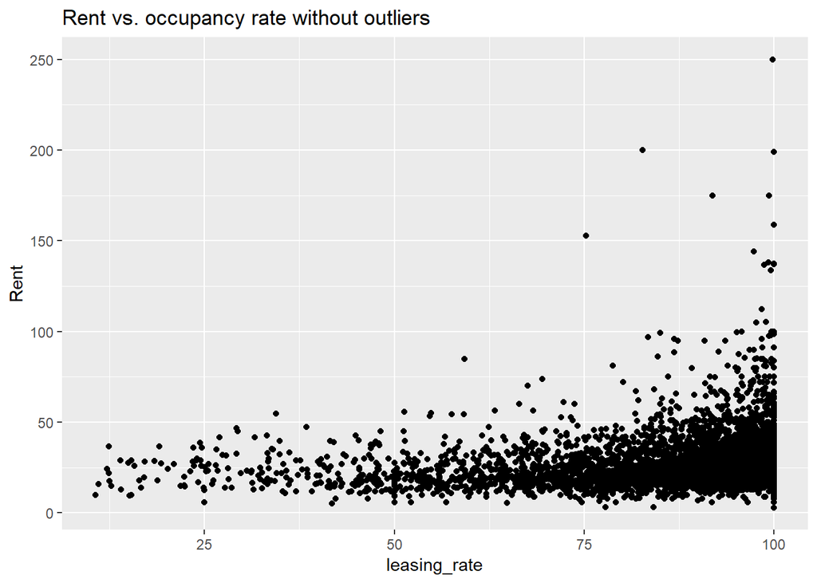

```r
mask = which(greenbuilding$leasing_rate > 10)
greenbuilding = greenbuilding[mask,]
ggplot(greenbuilding, aes(x=leasing_rate, y=Rent)) + geom_point()+ggtitle("Rent vs. occupancy rate without outliers")
```

### From the scatterplot we can see that there is a specific pattern when x is small. Therefore, it is correct to remove the outliers.

## 2. Should we use median or mean?

### *“I used the median rather than the mean, because there were still some outliers in the data, and the median is a lot more robust to outliers.”*

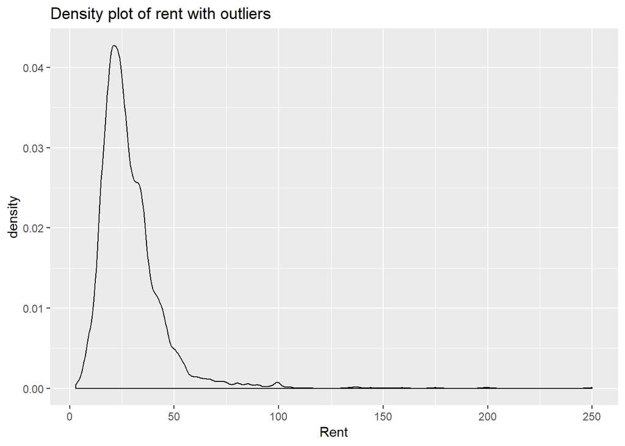

```r
ggplot(greenbuilding,aes(x=Rent))+geom_density()+ggtitle("Density plot of rent with outliers")
```

```r
mask2 = which(greenbuilding$Rent > 75)
paste("The number of outliers is",length(mask2))
```

```
## [1] "The number of outliers is 112"
```

```r
outliers = greenbuilding[mask2,]
remain = greenbuilding[-mask2,]
```

```r
library(gridExtra)

paste("The mean of rent of outliers is ",mean(outliers$Rent),", while the mean of rent of all buildings is ",mean(greenbuilding$Rent))
```

```
## [1] "The mean of rent of outliers is  103.209285714286 , while the mean of rent of all buildings is  28.5858458132569"
```

```r
paste("The mean of stories of outliers is ",mean(outliers$stories),", while the mean of stories of all buildings is ",mean(greenbuilding$stories))
```

```
## [1] "The mean of stories of outliers is  29.2946428571429 , while the mean of stories of all buildings is  13.8299257715848"
```

```r
paste("The number of green buildings among outliers is ",sum(outliers$green_rating=="1"),", while the number of outliers is ",dim(outliers)[1],". The fraction is ",sum(outliers$green_rating=="1")/dim(outliers)[1])
```

```
## [1] "The number of green buildings among outliers is  7 , while the number of outliers is  112 . The fraction is  0.0625"
```

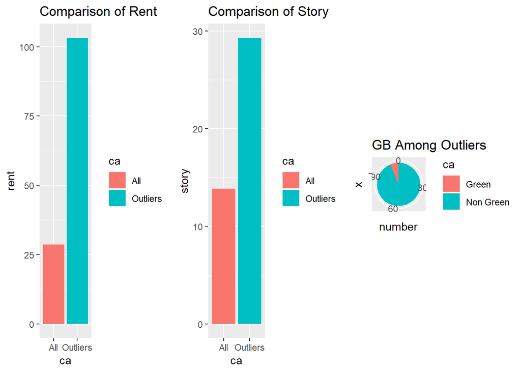

```r
rent_set = data.frame(ca=c("Outliers","All"),
                      rent=c(mean(outliers$Rent),mean(greenbuilding$Rent)))
p1=ggplot(data=rent_set,aes(x=ca,y=rent,fill=ca))+geom_bar(stat="identity")+ggtitle("Comparison of Rent")

story_set = data.frame(ca=c("Outliers","All"),
                      story=c(mean(outliers$stories),mean(greenbuilding$stories)))
p2=ggplot(data=story_set,aes(x=ca,y=story,fill=ca))+geom_bar(stat="identity")+ggtitle("Comparison of Story")

number_set = data.frame(ca=c("Green","Non Green"),
                      number=c(sum(outliers$green_rating=="1"),dim(outliers)[1]-sum(outliers$green_rating=="1")))
p3=ggplot(number_set,aes(x="",y=number,fill=ca))+geom_bar(width = 1, stat = "identity")+coord_polar("y", start=0)+ggtitle("GB Among Outliers")

grid.arrange(p1,p2,p3, ncol=3)
```

### From the graphs, we can see that first, most of these outliers have significantly higher rent than the average level. And then most of them have specifically high stories level which might be the reason of extremely high rent. Considering we are estimating for a 15-story building. These outliers might be less valuable for analysis. In addition, among these outliers, there exist few green buildings, which means we are not able to compare green and non-green building among these outleirs.In conclusion, we might not miss insight even if we remove these outliers.

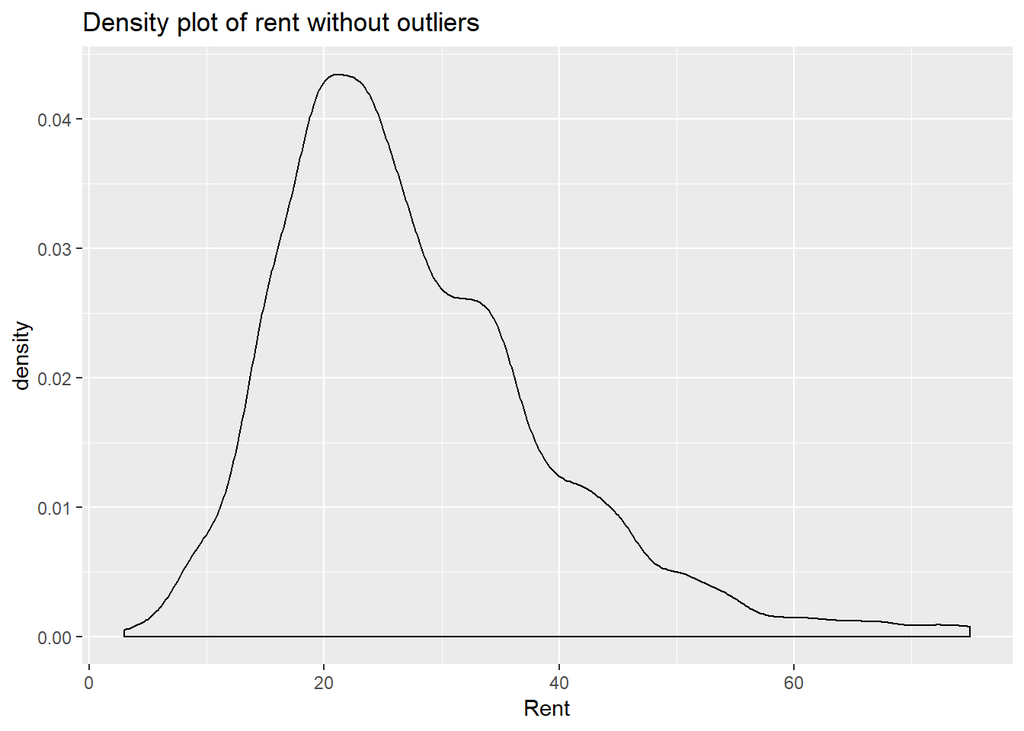

```r
ggplot(remain,aes(x=Rent))+geom_density()+ggtitle("Density plot of rent without outliers")
```

## 3. Should we just compare the mean rent of buildings from all areas?

### *“The median market rent in the non-green buildings was $25 per square foot per year, while the median market rent in the green buildings was $27.60 per square foot per year”*

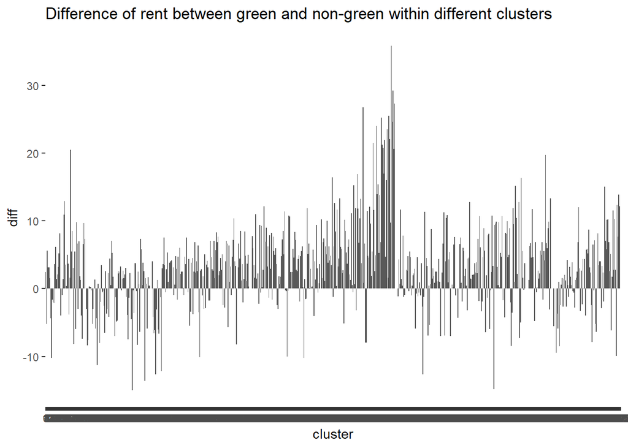

```r
library(dplyr)

mean_rent_green = remain %>% group_by(cluster) %>%
  summarise(diff=mean(Rent[green_rating==1])-mean(Rent[green_rating==0]))

ggplot(data=mean_rent_green, aes(x=cluster, y=diff)) +
  geom_bar(stat="identity",position=position_dodge())+ggtitle("Difference of rent between green and non-green within different clusters")
```

## 4. Future Estimation

### *“The median market rent in the non-green buildings was $25 per square foot per year, while the median market rent in the green buildings was $27.60 per square foot per year: about $2.60 more per square foot.”*

### Instead of revenue, we might be more interested in the future profit, which means we should also consider about the cost.

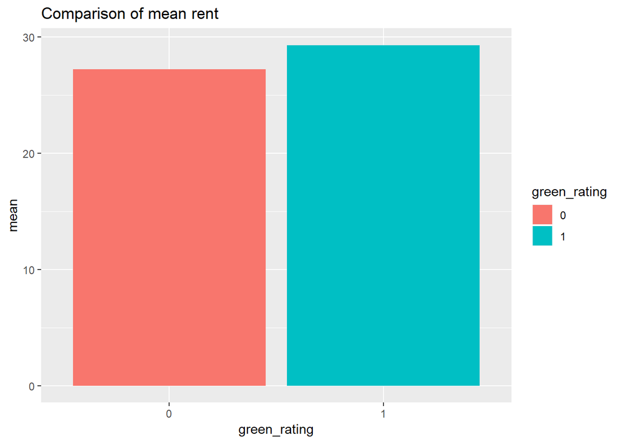

```r
remain["profit"]=remain["Rent"]-remain["Gas_Costs"]-remain["Electricity_Costs"]
remain=remain[,-c(19,20)]

profit_set = remain %>% group_by(green_rating) %>% summarise(mean=mean(profit))
ggplot(data=profit_set,aes(x=green_rating,y=mean,fill=green_rating))+geom_bar(stat="identity")+ggtitle("Comparison of mean rent")
```